# paper1

Kianté Fernandez

10/13/2020

```r
load("~/Dropbox/Medaglia_RiskBenefit_Neuroethics/Pilot_Data/Study1_Project/RiskBenefit_Neuroethics/data/Cleaned_Pilot/exclusions.2020.10.21.RData")
```

#Paper 1

## Exlclusion Criteria

In line with recommendations for studies conducted using Amazons Mechanical Turk (AMT) service, careful instructions and a priori exclusion criteria were applied to ensure data quality (Crump et al., 2013). Using a multi-method approach for the detection of careless/invalid responses in online samples, several data exclusion criteria were considered (Curran 2016). A total of 238 participants were excluded. Participants trials were excluded for either having a trial reaction times below 250 milli-seconds or above 90 seconds. Given that participants had ample time to respond to each question (up to as long until they made a decision), we reasoned that these subjects were not devoting sufficient attention to the task. Additionally, having considered trial wise exclusions, participants were also excluded for failure to complete at least 40 trials in the specified range. Finally, subjects were excluded for failure of passing four attention check items and a total survey completion time below five minutes. Our overall exclusion rate of 38% is well in line with the findings of research on quality control measures on MTurk (Crump et al., 2013; Downs et al., 2010; Paolacci & Chandler, 2014).

*Data analytic exclusions* To mitigate the effect of collinearity in our regressions, consistent with prior work a conservative variance inflation factor of 5 or higher was used to exclude subject models whose estimated coefficient were larger due to collinearity between risk and benefit (Craney et al., 2002). We also chose to the 5% of participants with the poorest model fit based on Nagelkerke’s $R^2$ (see also Walasek & Stewart, 2015), with the objective of removing participants who responded most randomly and inconsistently. Lastly, participants were excluded for selecting solely a single treatment option at or above 90% of the total amount of trials. These responses correspond with preferences that fall outside of the range we can reasonably capture using this paradigm.

##Risk, benefit marginal effects for each cog domain

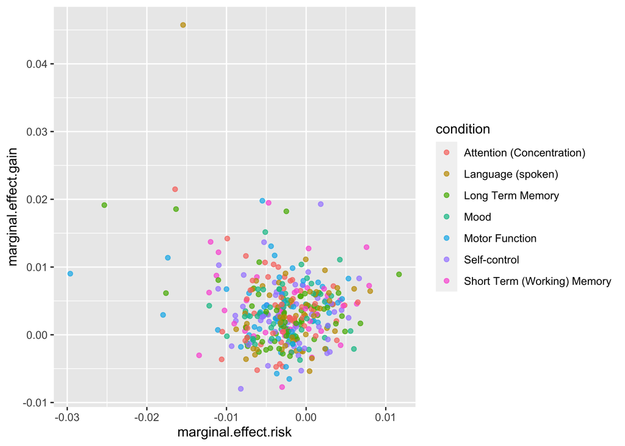

Descriptives for Risk by Cog domain

| type | condition | n | mean | sd | se | ci |
| --- | --- | --- | --- | --- | --- | --- |
| marginal.effect.risk | Attention (Concentration) | 54 | -0.0030983 | 0.0041893 | 0.0005701 | 0.0011434 |
| marginal.effect.risk | Language (spoken) | 56 | -0.0018943 | 0.0041066 | 0.0005488 | 0.0010997 |
| marginal.effect.risk | Long Term Memory | 62 | -0.0025827 | 0.0055488 | 0.0007047 | 0.0014091 |
| marginal.effect.risk | Mood | 57 | -0.0023723 | 0.0037360 | 0.0004949 | 0.0009913 |
| marginal.effect.risk | Motor Function | 49 | -0.0038141 | 0.0060149 | 0.0008593 | 0.0017277 |
| marginal.effect.risk | Self-control | 57 | -0.0025334 | 0.0041759 | 0.0005531 | 0.0011080 |
| marginal.effect.risk | Short Term (Working) Memory | 43 | -0.0024263 | 0.0053950 | 0.0008227 | 0.0016603 |

Descriptives for Gain by Cog domain

| type | condition | n | mean | sd | se | ci |
| --- | --- | --- | --- | --- | --- | --- |
| marginal.effect.gain | Attention (Concentration) | 54 | 0.0036665 | 0.0050460 | 0.0006867 | 0.0013773 |
| marginal.effect.gain | Language (spoken) | 56 | 0.0034332 | 0.0068865 | 0.0009202 | 0.0018442 |
| marginal.effect.gain | Long Term Memory | 62 | 0.0031186 | 0.0046460 | 0.0005900 | 0.0011799 |
| marginal.effect.gain | Mood | 57 | 0.0030456 | 0.0037520 | 0.0004970 | 0.0009955 |
| marginal.effect.gain | Motor Function | 49 | 0.0036809 | 0.0049861 | 0.0007123 | 0.0014322 |
| marginal.effect.gain | Self-control | 57 | 0.0028099 | 0.0046412 | 0.0006147 | 0.0012315 |
| marginal.effect.gain | Short Term (Working) Memory | 43 | 0.0040267 | 0.0051003 | 0.0007778 | 0.0015696 |

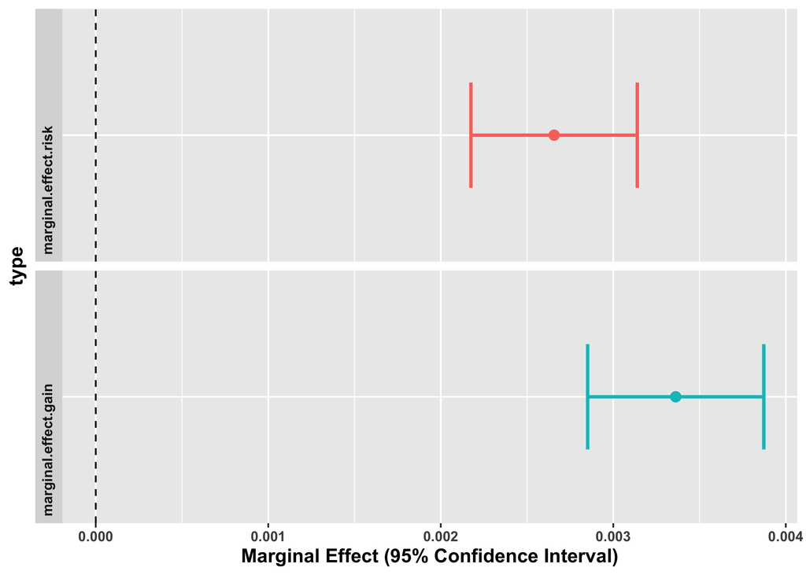